# Import Libraries

```python
!pip install plotly
!pip install pandas
!pip install numpy
!pip install matplotlib
!pip install seaborn==0.11.0
```

```python
#import packages
import pandas as pd
import numpy as np
import random as rnd
import matplotlib.pyplot as plt
from pandas.plotting import scatter_matrix
import seaborn as sb
import plotly.express as px
import math
```

# Read and check your dataset

```python
#load data with pandas
#change the directory to where the csv file is located
titanic_df = pd.read_csv("/mnt/local/data/titanic.csv")
```

```python
#return five first rows of the data frame
titanic_df.head(5)
```

|  | Survived | Pclass | Name | Gender | Age | Siblings/Spouses Aboard | Parents/Children Aboard | Fare |
| --- | --- | --- | --- | --- | --- | --- | --- | --- |
| 0 | 0 | 3 | Mr. Owen Harris Braund | male | 22.0 | 1 | 0 | 7.2500 |
| 1 | 1 | 1 | Mrs. John Bradley (Florence Briggs Thayer) Cum... | female | 38.0 | 1 | 0 | 71.2833 |
| 2 | 1 | 3 | Miss. Laina Heikkinen | female | 26.0 | 0 | 0 | 7.9250 |
| 3 | 1 | 1 | Mrs. Jacques Heath (Lily May Peel) Futrelle | female | 35.0 | 1 | 0 | 53.1000 |
| 4 | 0 | 3 | Mr. William Henry Allen | male | 35.0 | 0 | 0 | 8.0500 |

```python
# series
titanic_df["Gender"].value_counts()
```

```
male      573
female    314
Name: Gender, dtype: int64
```

```python
# check missing values in dataset
titanic_df.isnull().sum()
```

```
Survived                   0
Pclass                     0
Name                       0
Gender                     0
Age                        0
Siblings/Spouses Aboard    0
Parents/Children Aboard    0
Fare                       0
dtype: int64
```

```python
#details of each feature
titanic_df.describe()
```

|  | Survived | Pclass | Age | Siblings/Spouses Aboard | Parents/Children Aboard | Fare |
| --- | --- | --- | --- | --- | --- | --- |
| count | 887.000000 | 887.000000 | 887.000000 | 887.000000 | 887.000000 | 887.00000 |
| mean | 0.385569 | 2.305524 | 29.471443 | 0.525366 | 0.383315 | 32.30542 |
| std | 0.487004 | 0.836662 | 14.121908 | 1.104669 | 0.807466 | 49.78204 |
| min | 0.000000 | 1.000000 | 0.420000 | 0.000000 | 0.000000 | 0.00000 |
| 25% | 0.000000 | 2.000000 | 20.250000 | 0.000000 | 0.000000 | 7.92500 |
| 50% | 0.000000 | 3.000000 | 28.000000 | 0.000000 | 0.000000 | 14.45420 |
| 75% | 1.000000 | 3.000000 | 38.000000 | 1.000000 | 0.000000 | 31.13750 |
| max | 1.000000 | 3.000000 | 80.000000 | 8.000000 | 6.000000 | 512.32920 |

```python
#type of each feature
titanic_df.info()
```

```
<class 'pandas.core.frame.DataFrame'>
RangeIndex: 887 entries, 0 to 886
Data columns (total 8 columns):
 #   Column                   Non-Null Count  Dtype
---  ------                   --------------  -----
 0   Survived                 887 non-null    int64
 1   Pclass                   887 non-null    int64
 2   Name                     887 non-null    object
 3   Gender                   887 non-null    object
 4   Age                      887 non-null    float64
 5   Siblings/Spouses Aboard  887 non-null    int64
 6   Parents/Children Aboard  887 non-null    int64
 7   Fare                     887 non-null    float64
dtypes: float64(2), int64(4), object(2)
memory usage: 55.6+ KB
```

## Correlation

```
Survived                   1.000000
Pclass                     0.336528
Fare                       0.256179
Parents/Children Aboard    0.080097
Age                        0.059665
Siblings/Spouses Aboard    0.037082
Name: Survived, dtype: float64
```

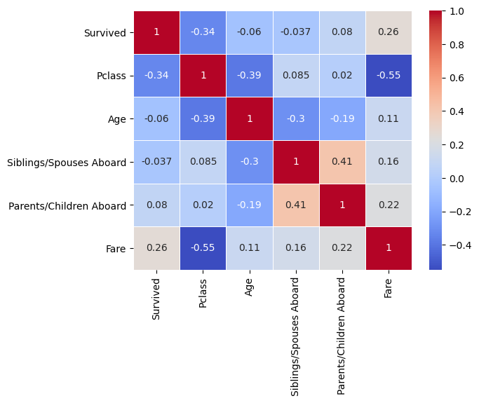

```python
print(titanic_df.corr()["Survived"].abs().sort_values(ascending=False))
fig, ax = plt.subplots() # Sample figsize in inches, figsize=(13,13)
sb.heatmap(titanic_df.corr(), annot=True, linewidths=.5, ax=ax, cmap="coolwarm")
```

## Bin the continuous values into discrete intervals

```python
#https://pandas.pydata.org/docs/reference/api/pandas.cut.html
#Bin the continuous values into discrete intervals.
#labels for age
age_labels = ['0-10', '11-20', '21-30', '31-40', '41-50', '51-60', '61-70', '71-80']
#use pandas cut to bin the continuous variable age
titanic_df['age_group'] = pd.cut(titanic_df.Age, range(0, 81, 10), labels=age_labels)
titanic_df.tail(5) #show the last five rows
```

|  | Survived | Pclass | Name | Gender | Age | Siblings/Spouses Aboard | Parents/Children Aboard | Fare | age_group |
| --- | --- | --- | --- | --- | --- | --- | --- | --- | --- |
| 882 | 0 | 2 | Rev. Juozas Montvila | male | 27.0 | 0 | 0 | 13.00 | 21-30 |
| 883 | 1 | 1 | Miss. Margaret Edith Graham | female | 19.0 | 0 | 0 | 30.00 | 11-20 |
| 884 | 0 | 3 | Miss. Catherine Helen Johnston | female | 7.0 | 1 | 2 | 23.45 | 0-10 |
| 885 | 1 | 1 | Mr. Karl Howell Behr | male | 26.0 | 0 | 0 | 30.00 | 21-30 |
| 886 | 0 | 3 | Mr. Patrick Dooley | male | 32.0 | 0 | 0 | 7.75 | 31-40 |

## Check the dataset with conditions.

```python
titanic_df[(titanic_df['Gender']=='female') & (titanic_df['Age'] > 61) ]
```

|  | Survived | Pclass | Name | Gender | Age | Siblings/Spouses Aboard | Parents/Children Aboard | Fare | age_group |
| --- | --- | --- | --- | --- | --- | --- | --- | --- | --- |
| 273 | 1 | 1 | Miss. Kornelia Theodosia Andrews | female | 63.0 | 1 | 0 | 77.9583 | 61-70 |
| 480 | 1 | 3 | Mrs. (Hedwig) Turkula | female | 63.0 | 0 | 0 | 9.5875 | 61-70 |
| 561 | 0 | 3 | Miss. (Marion Ogden) Meanwell | female | 62.0 | 0 | 0 | 8.0500 | 61-70 |
| 825 | 1 | 1 | Mrs. George Nelson (Martha Evelyn) Stone | female | 62.0 | 0 | 0 | 80.0000 | 61-70 |

```python
titanic_df[(titanic_df['Parents/Children Aboard'] == 3) ]
```

|  | Survived | Pclass | Name | Gender | Age | Siblings/Spouses Aboard | Parents/Children Aboard | Fare | age_group |
| --- | --- | --- | --- | --- | --- | --- | --- | --- | --- |
| 85 | 0 | 3 | Mr. William Neal Ford | male | 16.0 | 1 | 3 | 34.3750 | 11-20 |
| 434 | 1 | 2 | Mrs. Sidney (Emily Hocking) Richards | female | 24.0 | 2 | 3 | 18.7500 | 21-30 |
| 732 | 0 | 3 | Mrs. Edward (Margaret Ann Watson) Ford | female | 48.0 | 1 | 3 | 34.3750 | 41-50 |
| 770 | 1 | 2 | Mrs. Elizabeth (Eliza Needs) Hocking | female | 54.0 | 1 | 3 | 23.0000 | 51-60 |
| 854 | 1 | 3 | Mrs. Solomon (Latifa Qurban) Baclini | female | 24.0 | 0 | 3 | 19.2583 | 21-30 |

# [Bar plot] Distribution of Pclass in percentage

- Create a bar plot using pandas .plot with kind="bar" in orange color.
- Create the grid with a grid style as below.
- Do not forget to add all the details (e.g., title, labels, grid, description, legends if any).

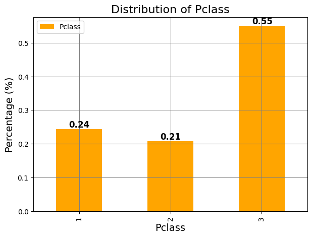

```python
plt.figure(figsize=(7,5))
ax = (titanic_df.Pclass.value_counts().sort_index()/len(titanic_df)).plot(kind='bar',  legend=True, color='orange')
for p in ax.patches:
    ax.annotate(round(p.get_height(), 2), (p.get_x() * 1.005 + 0.25, p.get_height() * 1.005 + 0.004), ha='center', weight='bold', size=12)
ax.grid(b=True, which='major', color='gray')
plt.title("Distribution of Pclass", fontsize=16)
plt.xlabel("Pclass", fontsize=14)
plt.ylabel("Percentage (%)", fontsize=14)
plt.show()
```

- Description: The Percentage by Pclass shows class 1 and 2 have almost same passengers but class 3 has almost twice passenger than class 1 and 2 on titanic.

# [Bar plot] Which Pclass had a better chance of survival?

- Use color 'green' for survivors and 'tab:olive' for non-survivors. Choose your own style for the grid.
- Use plt.bar(). Create stacked bar charts, vertical, with counts on y-axis.
- Use plt.bar(). Create stacked bar charts, horizontal, with percentage of survival rate on x-axis.
- Use Seaborn displot(). Create stacked bar charts, vertical, with counts on y-axis.
- Use Seaborn. Create grouped bar charts, horizontal, with "percentage on x-axis of survival rates". No need to display non-survivors but the grouped bar charts display gender. Use color to distinguish gender.
- Do not forget to add all the details (e.g., title, labels, grid, description, legends if any).

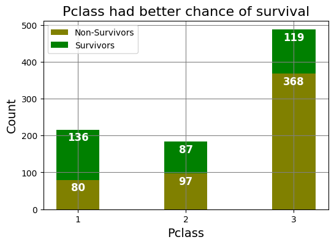

```python
#Use plt.bar(). Create stacked bar charts, vertical, with counts on y-axis.
pclass_survived=titanic_df.groupby(["Pclass", "Survived"]).size()
fig, ax = plt.subplots(figsize=(6,4))
ax.bar("1",pclass_survived[1][0],  width=0.4, label='Non-Survivors', color='olive')
ax.bar("1", pclass_survived[1][1],  width=0.4, bottom=pclass_survived[1][0], label='Survivors', color='green')
ax.bar("2", pclass_survived[2][0],  width=0.4, color='olive')
ax.bar("2", pclass_survived[2][1],  width=0.4, bottom=pclass_survived[2][0], color='green')
ax.bar("3", pclass_survived[3][0],  width=0.4, color='olive')
ax.bar("3", pclass_survived[3][1],  width=0.4, bottom=pclass_survived[3][0], color='green')
#putting pclass count with survived with negative offset
y_offset = -30
#adding label to each patch
for bar in ax.patches:
    ax.text(
      bar.get_x() + bar.get_width() / 2,
      bar.get_height() + bar.get_y() + y_offset,
      # actual value to show.
      round(bar.get_height()),
      # Center the labels and style them a bit.
      ha='center', color='w', weight='bold', size=12
    )
ax.legend()
ax.grid(b=True, which='major', color='gray')
plt.title("Pclass had better chance of survival", fontsize=16)
plt.xlabel("Pclass", fontsize=14)
plt.ylabel("Count", fontsize=14)
sb.set_style("darkgrid")
plt.show()
```

- Description: The Count by Pclass shows number of survivor passenger is high in class 1 as compared to the class 2 and 3 and number of non-survivor passenger is high in class 3 as compared to the class 1 and 2. It means Passengers in class 1 survive more and passengers in class 3 reach to death.

```python
# Check the counts of groupings
tempc = titanic_df.groupby(['Pclass','Survived'])['Pclass'].count()
temps = titanic_df.groupby(['Pclass'])['Pclass'].size()
tdiv = tempc/temps
print(tempc,"\n",temps,"\n",tdiv)
```

```
Pclass  Survived
1       0            80
        1           136
2       0            97
        1            87
3       0           368
        1           119
Name: Pclass, dtype: int64
 Pclass
1    216
2    184
3    487
Name: Pclass, dtype: int64
 Pclass  Survived
1       0           0.370370
        1           0.629630
2       0           0.527174
        1           0.472826
3       0           0.755647
        1           0.244353
Name: Pclass, dtype: float64
```

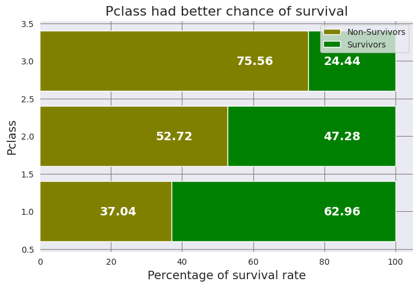

```python
# Use plt.bar(). Create stacked bar charts, horizontal, with percentage of survival rate on x-axis.
pclass_survived_per=(titanic_df.groupby(["Pclass", "Survived"])["Pclass"].count()/titanic_df.groupby(['Pclass'])['Pclass'].size())* 100
fig, ax = plt.subplots(figsize= (8, 5))
ax.barh(1, width= pclass_survived_per[1][0],  label='Non-Survivors', color='olive')
ax.barh(1, width= pclass_survived_per[1][1], left=pclass_survived_per[1][0], label='Survivors', color='green')
ax.barh(2, width= pclass_survived_per[2][0], color='olive')
ax.barh(2, width= pclass_survived_per[2][1], left=pclass_survived_per[2][0], color='green')
ax.barh(3, width= pclass_survived_per[3][0], color='olive')
ax.barh(3,width= pclass_survived_per[3][1], left=pclass_survived_per[3][0], color='green')

for p in ax.patches:
    ax.annotate(round(p.get_width(), 2), (p.get_x() + p.get_width() - 15 , p.get_height() + p.get_y() - 0.45), ha='center', color='w', weight='bold', size=14)
ax.grid(b=True, which='major', color='gray')

ax.legend()
ax.grid(b=True, which='major', color='gray')
plt.title("Pclass had better chance of survival", fontsize=16)
plt.xlabel("Percentage of survival rate", fontsize=14)
plt.ylabel("Pclass", fontsize=14)
plt.show()
```

- The Pclass by Percentage of Survival rate shows percentage of survivor passenger is high in class 1 as compared to the class 2 and 3 and percentage of non-survivor passenger is high in class 3 as compared to the class 1 and 2. It means Passengers in class 1 survive more and passengers in class 3 reach to death in higher percentage.

```python
pclass_survived
```

```
Pclass  Survived
1       0            80
        1           136
2       0            97
        1            87
3       0           368
        1           119
dtype: int64
```

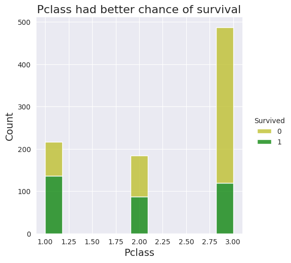

```python
#Use Seaborn displot(). Create stacked bar charts, vertical, with counts on y-axis.

plt.figure(figsize=(4, 10))
sb.displot(data=titanic_df, x='Pclass', hue='Survived', multiple= 'stack', palette=['tab:olive', 'green'])
plt.title('Pclass had better chance of survival', fontsize=16)
plt.xlabel("Pclass", fontsize=14)
plt.ylabel("Count", fontsize=14)
plt.show()
```

- The Count by Pclass shows number of survivor passenger is high in class 1 as compared to the class 2 and 3 and number of non-survivor passenger is high in class 3 as compared to the class 1 and 2. It means Passengers in class 1 survive more and passengers in class 3 reach to death in higher order.

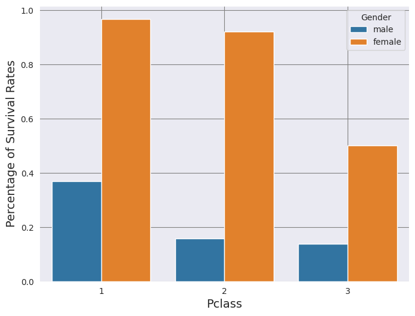

```python
#Use Seaborn. Create grouped bar charts, horizontal, with "percentage on x-axis of survival rates".
#No need to display non-survivors but the grouped bar charts display gender. Use color to distinguish gender.
plt.figure(figsize=(8,6))
sb.barplot(x="Pclass", y='Survived', hue="Gender",  estimator=np.mean, order = [1,2,3],  data= titanic_df, ci=None)
plt.grid(b=True, which='major', color='gray')
plt.ylabel("Percentage of Survival Rates", fontsize=14)
plt.xlabel("Pclass", fontsize=14)
plt.ylabel("Percentage of Survival Rates", fontsize=14)
plt.show()
```

# [Bar plot] Which age_group had a better chance of survival considering the gender?

- Use Seaborn. Create grouped bar charts, vertical, with "percentage of survival rates on y-axis and age_group on x-axis".
- Refer to 'Bin the continuous values into discrete intervals' described above.
- Hue represents gender.
- Do not forget to add all the details (e.g., title, labels, grid, description, legends if any).

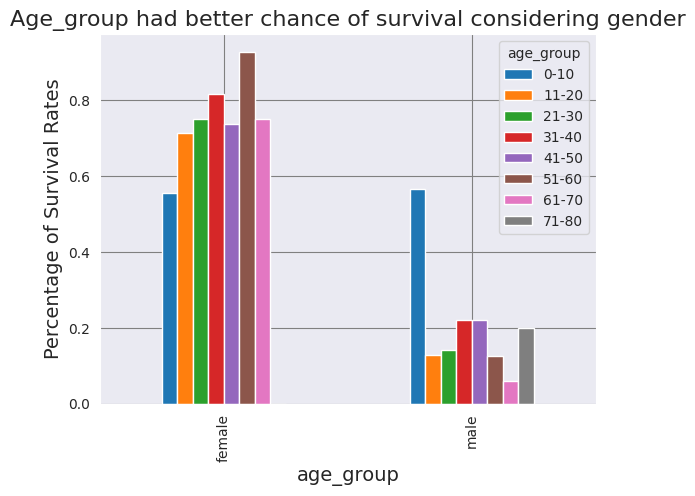

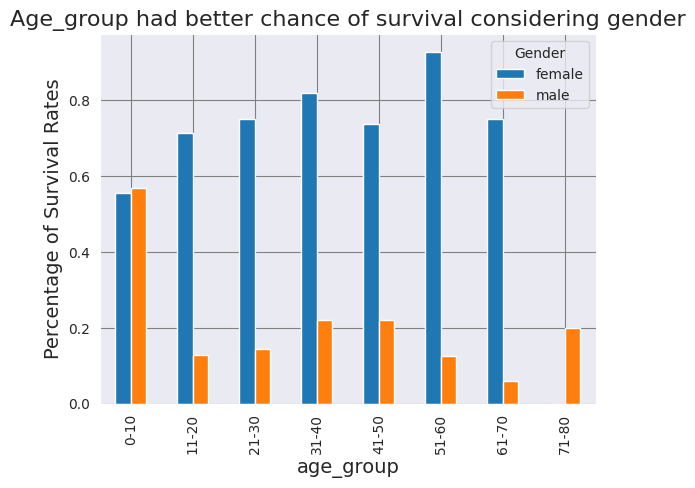

```python
# I have ploted this graph my two different methods
# 1) by following the instruction you mentioned in the review docx file
# 2) by following the instructions you mentioned above to this cell.

table= titanic_df.pivot_table(index='Gender', columns='age_group', values='Survived', aggfunc=np.mean)
table.plot(kind='bar')
plt.grid(b=True, which='major', color='gray', linestyle='-')
plt.title("Age_group had better chance of survival considering gender", fontsize=16)
plt.xlabel("age_group", fontsize=14)
plt.ylabel("Percentage of Survival Rates", fontsize=14)
plt.show()


table1= titanic_df.pivot_table(index='age_group', columns='Gender', values='Survived', aggfunc=np.mean)
table1.plot(kind='bar')
plt.grid(b=True, which='major', color='gray')
plt.title("Age_group had better chance of survival considering gender", fontsize=16)
plt.xlabel("age_group", fontsize=14)
plt.ylabel("Percentage of Survival Rates", fontsize=14)
plt.show()
```

# [Pie plot] Distribution of Pclass in percentage.

- Use 3 different colors to color the pie plot for the three Pclasses.
- Start the pie start angle from 0 degrees.
- Round to two decimal places to show percentage numbers and add '%' after the number.
- Use the 'explode' parameter to distinguish the largest distribution of Pclass.
- Do not forget to add all the details (e.g., title, labels, grid, description, legends if any).

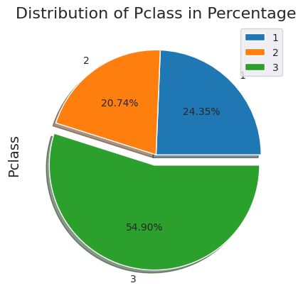

```python
explode = (0, 0, 0.1)
(titanic_df.Pclass.value_counts().sort_index()/len(titanic_df)).plot(kind='pie', explode=explode, grid=True, legend=True, startangle=0, shadow=True, autopct='%.2f%%')
plt.title("Distribution of Pclass in Percentage",fontsize=16)
plt.ylabel('Pclass', fontsize=14)
plt.show()
```

- Pie plot shows class 3 has 54.90% of passengers on titanic while class 2 has 20.74% and class 1 has 24.35%. It means class 3 carry more passengers.

# [Histogram] Distribution of Siblings/Spouses Aboard and Parents/Children Aboard.

- Create a histogram of the distribution of Siblings/Spouses Aboard with 4 bins.
- Create a histogram of the distribution of Parents/Children Aboard with 3 bins.
- Do not forget to add all the details (e.g., title, labels, grid, description, legends if any).

```python
titanic_df['Siblings/Spouses Aboard'].value_counts()
```

```
0    604
1    209
2     28
4     18
3     16
8      7
5      5
Name: Siblings/Spouses Aboard, dtype: int64
```

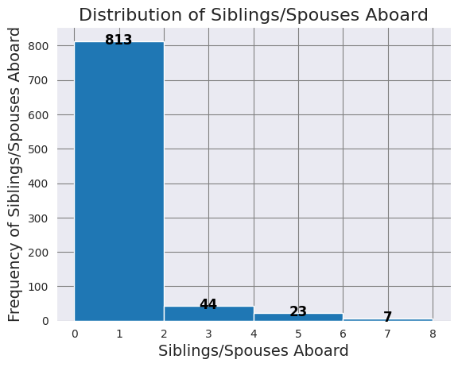

```python
ax = titanic_df['Siblings/Spouses Aboard'].plot(kind='hist', bins=4)

for bar in ax.patches:
    ax.text(
      bar.get_x() + bar.get_width() / 2,
      bar.get_height() + bar.get_y() - 10,
      round(bar.get_height()),
      ha='center', color='black', weight='bold', size=12
    )

plt.grid(b=True, which='major', color='gray')
plt.title("Distribution of Siblings/Spouses Aboard", fontsize=16)
plt.xlabel("Siblings/Spouses Aboard", fontsize=14)
plt.ylabel("Frequency of Siblings/Spouses Aboard", fontsize=14)
plt.show()
```

- The tallest bar in sibling/spouse aboard representing a bin between 0 to 2 shows 813 passengers, while 2nd bin between 2 to 4 shows 44 passengers and 3rd bin is between 4 to 6 shows 23 passengers and 4th bin is between 6 to 8 shows 7 passengers
- The Frequency of Sibling/Spouses Aboard by Siblings/Spouses Aboard shows those passensers who had sibling/spouse aboard between 0 to 2 has more frequency as compared to others.

```python
titanic_df['Parents/Children Aboard'].value_counts()
```

```
0    674
1    118
2     80
5      5
3      5
4      4
6      1
Name: Parents/Children Aboard, dtype: int64
```

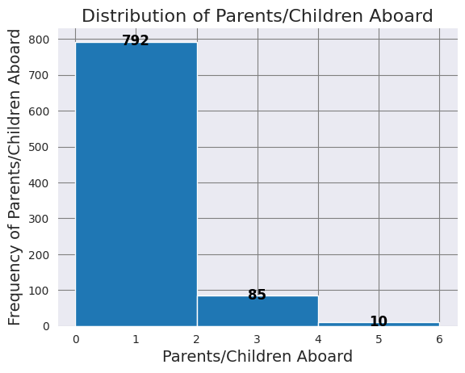

```python
ax= titanic_df['Parents/Children Aboard'].plot(kind='hist', bins=3)

for bar in ax.patches:
    ax.text(
      bar.get_x() + bar.get_width() / 2,
      bar.get_height() + bar.get_y() - 10,
      round(bar.get_height()),
      ha='center', color='black', weight='bold', size=12
    )


plt.grid(b=True, which='major', color='gray')
plt.title("Distribution of Parents/Children Aboard", fontsize=16)
plt.xlabel("Parents/Children Aboard", fontsize=14)
plt.ylabel("Frequency of Parents/Children Aboard", fontsize=14)
plt.show()
```

- The tallest bar in Parents/Children aboard representing a bin between 0 to 2 shows 792 passengers, while 2nd bin between 2 to 4 shows 85 passengers and 3rd bin is between 4 to 6 shows 10 passengers.
- The Frequency of Parents/Children Aboard by Parents/Children Aboard shows those passensers who had Parents/Children Aboard between 0 to 2 has more frequency as compared to others.

# [Boxplot] Which ss_group ('0', '1-2', '3-6', and '7-8') has survived more?

- Refer to how the continuous variable age is categorized into age_group from lecture and section above-'Bin the continuous values into discrete intervals'. Use pd.cut().
- Categorize Siblings/Spouses Aboard into 4 bins, '0', '1-2', '3-6', and '7-8' and name the column ss_group.
- Show mean value with a marker of your style.
- With the ss_group, draw box plots regarding ss_group (x) and age (y). Use color to present survivors/non-survivors. Which ss_group ('0', '1-2', '3-6', and '7-8') has survived more?
- Do not forget to add all the details (e.g., title, labels, grid, description, legends if any).

```python
# Use pd.cut to categorize the 'Siblings/Spouses Aboard' into bins with '0', '1-2', '3-6', and '7-8'.
# labels for siblings or spouse
# ss_labels = ['0', '1-2', '3-6', '7-8']
bins = pd.IntervalIndex.from_tuples([(0, 1), (1, 3), (3, 6), (7, 8)], closed='left')
ss_labels = ['0', '1-2', '3-6', '7-8']
#use pandas cut to bin the continuous variable age
titanic_df['ss_group'] = pd.cut(titanic_df['Siblings/Spouses Aboard'], bins=[0, 1, 3, 6, 9], labels= ss_labels, right=False)
titanic_df['ss_group'].categories= ['0', '1-2', '3-6', '7-8']
titanic_df[(titanic_df['Siblings/Spouses Aboard']==8)].head(5) #show the last five rows
```

|  | Survived | Pclass | Name | Gender | Age | Siblings/Spouses Aboard | Parents/Children Aboard | Fare | age_group | ss_group |
| --- | --- | --- | --- | --- | --- | --- | --- | --- | --- | --- |
| 158 | 0 | 3 | Master. Thomas Henry Sage | male | 5.0 | 8 | 2 | 69.55 | 0-10 | 7-8 |
| 179 | 0 | 3 | Miss. Constance Gladys Sage | female | 8.0 | 8 | 2 | 69.55 | 0-10 | 7-8 |
| 200 | 0 | 3 | Mr. Frederick Sage | male | 17.0 | 8 | 2 | 69.55 | 11-20 | 7-8 |
| 322 | 0 | 3 | Mr. George John Jr Sage | male | 20.0 | 8 | 2 | 69.55 | 11-20 | 7-8 |
| 788 | 0 | 3 | Miss. Stella Anna Sage | female | 21.0 | 8 | 2 | 69.55 | 21-30 | 7-8 |

```python
# Check the rows whether 'Siblings/Spouses Aboard' value matches the bins with titanic_df.iloc[].
# Check rows 118, 119, 372, 838, 845, 846, 859.
# > Write your code here.
rows= [118, 119, 372, 838, 845, 846, 859]
for i in rows:
    print(titanic_df.iloc[i])
```

```
Survived                                                  0
Pclass                                                    3
Name                       Miss. Ellis Anna Maria Andersson
Gender                                               female
Age                                                     2.0
Siblings/Spouses Aboard                                   4
Parents/Children Aboard                                   2
Fare                                                 31.275
age_group                                              0-10
ss_group                                                3-6
Name: 118, dtype: object
Survived                                            0
Pclass                                              2
Name                       Mr. Stanley George Hickman
Gender                                           male
Age                                              21.0
Siblings/Spouses Aboard                             2
Parents/Children Aboard                             0
Fare                                             73.5
age_group                                       21-30
ss_group                                          1-2
Name: 119, dtype: object
Survived                                           0
Pclass                                             3
Name                       Miss. Stina Viola Palsson
Gender                                        female
Age                                              3.0
Siblings/Spouses Aboard                            3
Parents/Children Aboard                            1
Fare                                          21.075
age_group                                       0-10
ss_group                                         3-6
Name: 372, dtype: object
Survived                                        1
Pclass                                          1
Name                       Miss. Augusta Serepeca
Gender                                     female
Age                                          30.0
Siblings/Spouses Aboard                         0
Parents/Children Aboard                         0
```

[output cut: 22 more lines]

```
Fare                                                       31.275
age_group                                                    0-10
ss_group                                                      3-6
Name: 846, dtype: object
Survived                                          0
Pclass                                            3
Name                       Miss. Dorothy Edith Sage
Gender                                       female
Age                                            14.0
Siblings/Spouses Aboard                           8
Parents/Children Aboard                           2
Fare                                          69.55
age_group                                     11-20
ss_group                                        7-8
Name: 859, dtype: object
```

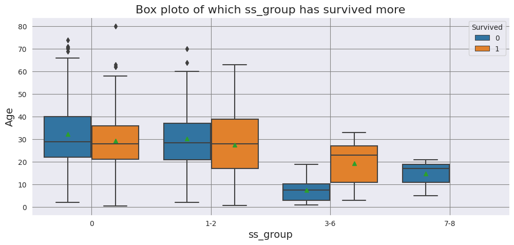

```python
# define plot size
plt.figure(figsize = (12,5))
sb.boxplot(x='ss_group', y='Age', hue='Survived', data=titanic_df,  showmeans = True)
plt.grid(b=True, which='major', color='gray')
plt.title('Box ploto of which ss_group has survived more', fontsize=16)
plt.xlabel("ss_group", fontsize=14)
plt.ylabel("Age", fontsize=14)
plt.show()
```

- The box plot of Age by ss_group shows that ss_group of 1-2 having age in middle of 18 to 40 survived more and ss_group 3-6 having age in middle of 10 to 28 survived more as compared to other ss_groups.

# [Scatterplot] For the passengers younger than 20, is there a difference, by gender, between survivors who had no sibling/spouse vs. who had one sibling/spouse? What about vs. more than one sibling/spouse?

- Use Seaborn's relplot() to draw two scatterplots with age and Siblings/Spouses Aboard. Left view showing male and right view showing female.
- Hue represents survivors/non-survivors, size represents fare, and different shapes represent Pclass.
- Check the difference between survivors by gender, age, Siblings/Spouses Aboard, fare, and Pclass information.
- For the passengers younger than 20, is there a difference, by gender, between survivors who had no siblings vs. who had one sibling?
- Do not forget to add all the details (e.g., title, labels, grid, description, legends if any).

```python
titanic_df.head()
```

|  | Survived | Pclass | Name | Gender | Age | Siblings/Spouses Aboard | Parents/Children Aboard | Fare | age_group | ss_group |
| --- | --- | --- | --- | --- | --- | --- | --- | --- | --- | --- |
| 0 | 0 | 3 | Mr. Owen Harris Braund | male | 22.0 | 1 | 0 | 7.2500 | 21-30 | 1-2 |
| 1 | 1 | 1 | Mrs. John Bradley (Florence Briggs Thayer) Cum... | female | 38.0 | 1 | 0 | 71.2833 | 31-40 | 1-2 |
| 2 | 1 | 3 | Miss. Laina Heikkinen | female | 26.0 | 0 | 0 | 7.9250 | 21-30 | 0 |
| 3 | 1 | 1 | Mrs. Jacques Heath (Lily May Peel) Futrelle | female | 35.0 | 1 | 0 | 53.1000 | 31-40 | 1-2 |
| 4 | 0 | 3 | Mr. William Henry Allen | male | 35.0 | 0 | 0 | 8.0500 | 31-40 | 0 |

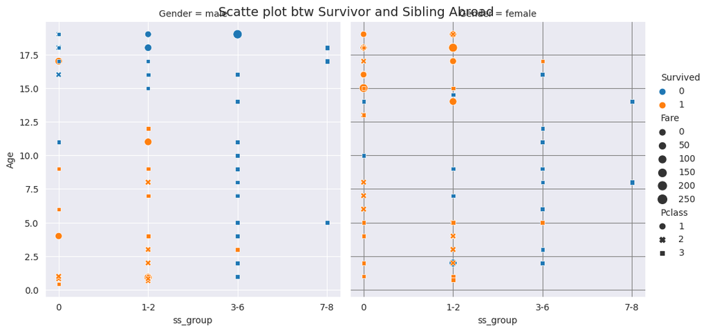

```python
plt.figure(figsize = (12,5))
x= sb.relplot(y='Age' , x='ss_group' , col='Gender', hue= 'Survived', size='Fare', sizes=(40, 100), style='Pclass', estimator=None, data=titanic_df[(titanic_df['Age']<20)])
plt.grid(b=True, which='major', color='gray')
x.fig.suptitle('Scatte plot btw Survivor and Sibling Abroad', fontsize=14)
plt.show()
```

# [Scatterplot] A plot with age, fare, ss_group, and survivors/non-survivors.

- Use Seaborn scatterplot() to draw a scatterplot with age (x) and fare (y).
- Hue represents ss_group, size represents ss_group with bigger values showing bigger circles, and survivor/non-survivor in different shapes.
- Use size_order = ['7-8', '3-6', '1-2', '0'] for size ordering.
- Use style_order to show O for survivors and X for non-survivors.
- In your description, write your overall explanation of the survivors and non-survivors by age, fare, and sibling/spouse aboard information.
- Do not forget to add all the details (e.g., title, labels, grid, description, legends if any).

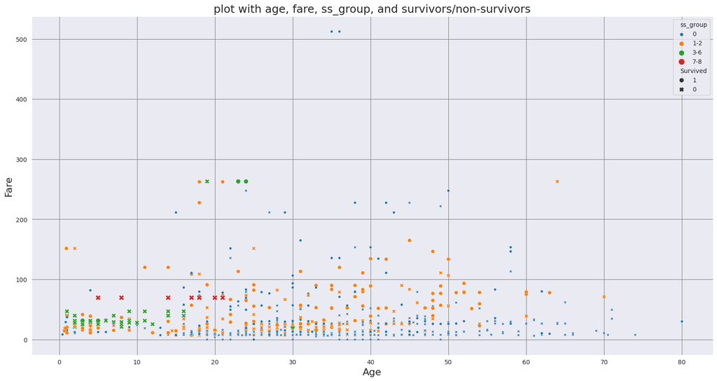

```python
plt.figure(figsize=(20, 10))
markers = {0: "X", 1: "o"}
sb.scatterplot(x="Age", y="Fare", hue="ss_group", size="ss_group", size_order=['7-8', '3-6', '1-2', '0'],  style="Survived", style_order=[1, 0], data=titanic_df);
plt.grid(b=True, which='major', color='gray')
plt.title("plot with age, fare, ss_group, and survivors/non-survivors", fontsize=18)
plt.xlabel("Age", fontsize=16)
plt.ylabel("Fare", fontsize=16)
plt.show()
```

# [Heatmap] Find the "age_group - Siblings/Spouses Aboard" and "age_group -Parents/Children Aboard" pairs with survivor rate over 60%.

- Create a heatmap from a pivot table of age_group and Siblings/Spouses Aboard. Get the percentage of survivors for each cell and find those pairs of 'age_group - Siblings/Spouses Aboard' that shows survivor rate over 60%.
- Create a heatmap from a pivot table of age_group and Parents/Children Aboard. Get the percentage of survivors for each cell and find those pairs of 'age_group - Siblings/Spouses Aboard' that shows survivor rate over 60%.
- Round to three decimal place to show percentage numbers.
- Do not forget to add all the details (e.g., title, labels, grid, description, legends if any).

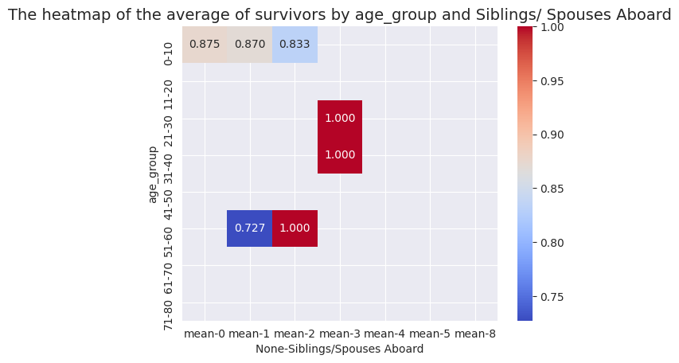

```python
# titanic_df.groupby(['age_group', 'Siblings/Spouses Aboard']).Survived.mean()
pivot = pd.pivot_table(titanic_df, index='age_group', columns='Siblings/Spouses Aboard', values='Survived', aggfunc={np.mean})
pivot= pivot[(pivot['mean']) > 0.60]
sb.heatmap(pivot, cmap='coolwarm', annot=True, fmt=".3f")
plt.grid()
plt.title('The heatmap of the average of survivors by age_group and Siblings/ Spouses Aboard', fontsize=14)
```

- The heatmap of agr_group by Siblings/Spouses Aboard there are few age group who had survival rate more than 60 % else are below the 60 %.

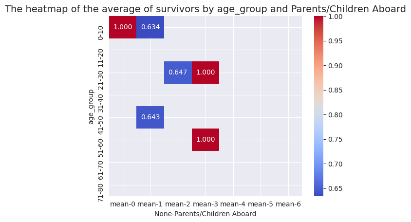

```python
pivot = pd.pivot_table(titanic_df, index='age_group', columns='Parents/Children Aboard', values='Survived', aggfunc={np.mean})
pivot= pivot[(pivot['mean']) > 0.60]
sb.heatmap(pivot, cmap='coolwarm', annot=True, fmt=".3f")
plt.grid()
plt.title('The heatmap of the average of survivors by age_group and Parents/Children Aboard', fontsize=14)
```

- The heatmap of agr_group by Parents/Children Aboard there are few age group who had survival rate more than 60 % else are below the 60 %..

# [3D interaction] For the passengers younger than 20, is there a difference, by gender, between survivors who had no parents/children aboard vs. who had one parent/child aboard? What about vs. more than one parent/child aboard?

- Use plotly px.scatter_3d to create a 3D plot.
- Use color to represent surviors/non-survivors and different symbols to represent Pclass.
- Use size to represent 'Siblings/Spouses Aboard'.
- Use hover_data=[] to show all features available.
- The symbol for Pclass 1 is given below. The title needs to be updated.
- Do not forget to add all the details (e.g., title, labels, grid, description, legends if any).

```python
# Since Siblings/Spouses Aboard includes zero values, size zero needs to be visible when plotting
ssSize = np.array(titanic_df['Siblings/Spouses Aboard'])
ssSize = (ssSize + 1)

# Q10> Write your code here.
fig = px.scatter_3d(titanic_df, x='Gender', y='Age', z='Survived',
              color='Survived', size=ssSize, size_max=30,
              symbol='Pclass', opacity=0.8,
              hover_data=['Fare','Parents/Children Aboard'],
              color_continuous_scale='Portland')



fig.for_each_trace(
    lambda trace: trace.update(marker_symbol="diamond") if trace.name == "1" else (),
)

fig.update_traces(marker=dict(line=dict(width=1,
                                        color='black')),
                  selector=dict(mode='markers'))

mytitle = "" #"Title of this 3D"
fig.update_layout(
    title={
        'text': mytitle,
        'y':0.9,
        'x':0.5,
        'xanchor': 'center',
        'yanchor': 'top'},
    margin=dict(l=0, r=0, b=0, t=0),
    legend=dict(
        yanchor="top",
        y=0.99,
        xanchor="left",
        x=0.01
))

fig.show()
```

[output not shown]

```python
import os
os.system('jupyter nbconvert --to html shehzad_visPython.ipynb')
```